# Time Series - Assignment

Simon Munzert

30.09.2017

### Assignment 04: Time Series

##### 1. Traffic accidents in California

The dataset `traffic2` from the `wooldridge` package contains 108 monthly observations on automobile accidents, traffic laws, and some other variables for California from January 1981 through December 1989. Use this dataset to tackle the following tasks.

(a) Generate an `xts` time series object from the dataset and plot the time series of total accidents.

```r
data(traffic2)
traffic2_ts <- ts(traffic2, frequency = 12, start = 1981)
traffic2_xts <- as.xts(traffic2_ts)
```

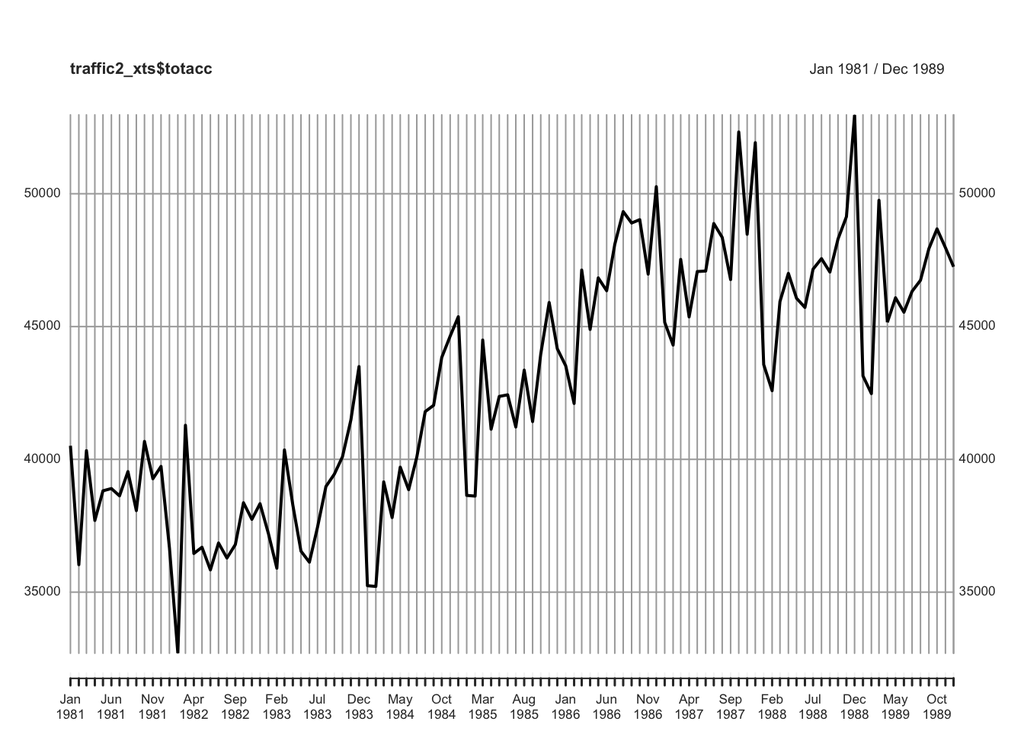

```r
plot(traffic2_xts$totacc)
```

(b) During what month and year did California’s seat belt law take effect? And when did the highway speed limit increase to 65 miles per hour? Try to indicate these dates in the time series plot using red vertical lines! *Hint:* Use the `addEventLines()` to add the lines!

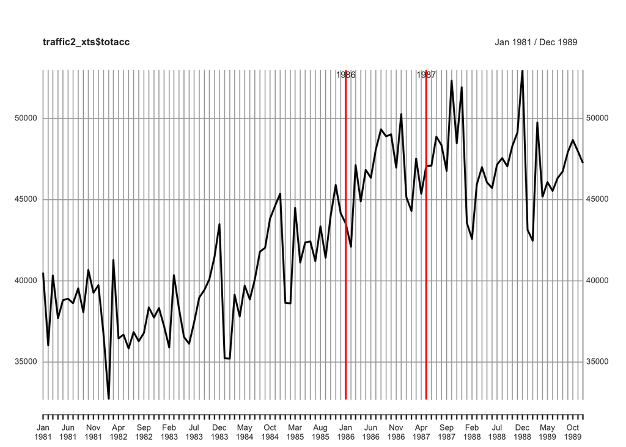

```r
invisible(plot(traffic2_xts$totacc))
invisible(addEventLines(traffic2_xts[as.logical(diff(traffic2_xts$beltlaw)),], lwd = 2, col = "red"))
addEventLines(traffic2_xts[as.logical(diff(traffic2_xts$spdlaw)),], lwd = 2, col = "red")
```

(c) Regress the variable `totacc` on a linear time trend and 11 monthly dummy variables, using January as the base month. Interpret the coefficient estimate on the time trend. Would you say there is seasonality in total accidents?

```r
summary(lm(totacc ~ t + feb + mar + apr + may + jun + jul + aug + sep + oct + nov + dec, data = traffic2_xts))
```

```
##
## Call:
## lm(formula = totacc ~ t + feb + mar + apr + may + jun + jul +
##     aug + sep + oct + nov + dec, data = traffic2_xts)
##
## Residuals:
##     Min      1Q  Median      3Q     Max
## -4294.3 -1766.4  -228.4  1513.2  5704.9
##
## Coefficients:
##             Estimate Std. Error t value Pr(>|t|)
## (Intercept) 34689.43     809.41  42.858  < 2e-16 ***
## t             116.68       6.86  17.008  < 2e-16 ***
## feb         -1641.90    1041.32  -1.577  0.11818
## mar          3355.98    1041.38   3.223  0.00174 **
## apr           775.86    1041.50   0.745  0.45814
## may          1368.85    1041.66   1.314  0.19197
## jun           882.18    1041.86   0.847  0.39927
## jul          1636.39    1042.11   1.570  0.11968
## aug          2325.82    1042.40   2.231  0.02802 *
## sep          1816.82    1042.74   1.742  0.08468 .
## oct          3572.58    1043.12   3.425  0.00091 ***
## nov          3048.35    1043.55   2.921  0.00436 **
## dec          4254.90    1044.03   4.075 9.53e-05 ***
## ---
## Signif. codes:  0 '***' 0.001 '**' 0.01 '*' 0.05 '.' 0.1 ' ' 1
##
## Residual standard error: 2209 on 95 degrees of freedom
## Multiple R-squared:  0.796,  Adjusted R-squared:  0.7702
## F-statistic: 30.89 on 12 and 95 DF,  p-value: < 2.2e-16
```

(d) Use STL to decompose the `injacc` as well as the `fatacc` time series and plot the results. What do the graphs tell you about the seasonality and trends on these two variables?

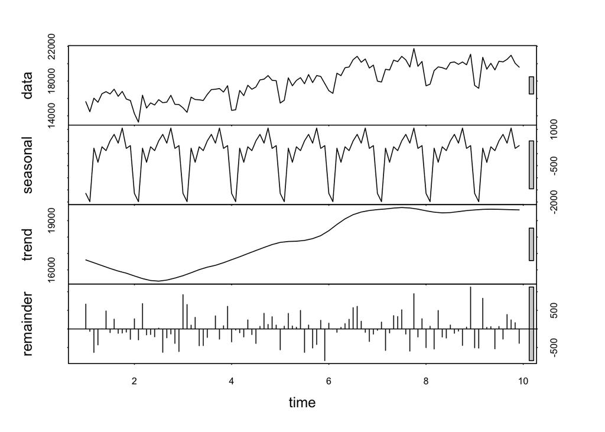

```r
plot(stl(traffic2_xts$injacc, s.window = "periodic"))
```

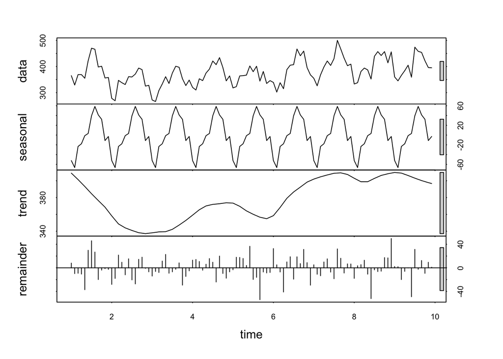

```r
plot(stl(traffic2_xts$fatacc, s.window = "periodic"))
```

(e) Add to the regression from (c) the variables `wkends`, `unem`, `spdlaw`, and `beltlaw`. Discuss the coefficient on the unemployment variable. Does its sign and magnitude make sense to you?

```r
summary(lm(totacc ~ t + feb + mar + apr + may + jun + jul + aug + sep + oct + nov + dec +
                    wkends + unem + beltlaw + spdlaw, data = traffic2_xts))
```

```
##
## Call:
## lm(formula = totacc ~ t + feb + mar + apr + may + jun + jul +
##     aug + sep + oct + nov + dec + wkends + unem + beltlaw + spdlaw,
##     data = traffic2_xts)
##
## Residuals:
##     Min      1Q  Median      3Q     Max
## -3710.0 -1092.4  -175.4   789.3  4127.7
##
## Coefficients:
##             Estimate Std. Error t value Pr(>|t|)
## (Intercept) 41571.14    2695.16  15.424  < 2e-16 ***
## t              42.96      11.02   3.900 0.000184 ***
## feb         -1271.85     759.10  -1.675 0.097273 .
## mar          3261.64     717.48   4.546 1.68e-05 ***
## apr           486.07     728.28   0.667 0.506194
## may          1061.04     723.66   1.466 0.146038
## jun           990.07     735.46   1.346 0.181581
## jul          2169.60     713.61   3.040 0.003086 **
## aug          2454.73     718.47   3.417 0.000950 ***
## sep          1868.03     738.32   2.530 0.013121 *
## oct          3623.97     724.37   5.003 2.74e-06 ***
## nov          3350.09     736.76   4.547 1.67e-05 ***
## dec          4456.35     729.29   6.111 2.42e-08 ***
## wkends        138.43     161.32   0.858 0.393083
## unem         -843.55     145.14  -5.812 9.02e-08 ***
## beltlaw      4325.94     608.15   7.113 2.51e-10 ***
## spdlaw      -2059.88     538.45  -3.826 0.000239 ***
## ---
## Signif. codes:  0 '***' 0.001 '**' 0.01 '*' 0.05 '.' 0.1 ' ' 1
##
## Residual standard error: 1506 on 91 degrees of freedom
## Multiple R-squared:  0.9092, Adjusted R-squared:  0.8933
## F-statistic: 56.96 on 16 and 91 DF,  p-value: < 2.2e-16
```

(f) The variable `prcfat` is the percentage of accidents resulting in at least one fatality. Use STL to decompose the corresponding time series; then run the regression from (e) again but now use `prcfat` as the dependent variable. Interpret the estimated effects, in particular those of the policy variables.

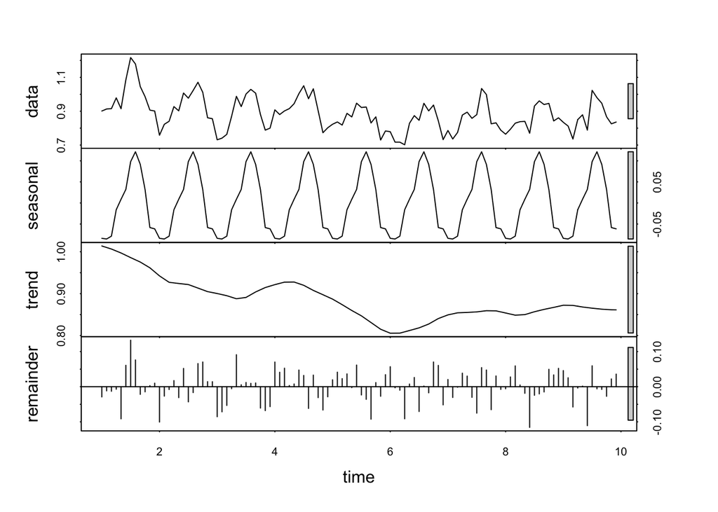

```r
plot(stl(traffic2_xts$prcfat, s.window = "periodic"))
```

```r
summary(lm(prcfat ~ t + feb + mar + apr + may + jun + jul + aug + sep + oct + nov + dec +
                    wkends + unem + beltlaw + spdlaw, data = traffic2_xts))
```

```
##
## Call:
## lm(formula = prcfat ~ t + feb + mar + apr + may + jun + jul +
##     aug + sep + oct + nov + dec + wkends + unem + beltlaw + spdlaw,
##     data = traffic2_xts)
##
## Residuals:
##       Min        1Q    Median        3Q       Max
## -0.132085 -0.032573  0.000621  0.038226  0.132080
##
## Coefficients:
##               Estimate Std. Error t value Pr(>|t|)
## (Intercept)  1.030e+00  1.030e-01  10.003 2.52e-16 ***
## t           -2.235e-03  4.208e-04  -5.312 7.66e-07 ***
## feb          8.607e-04  2.900e-02   0.030 0.976384
## mar          9.226e-05  2.741e-02   0.003 0.997321
## apr          5.822e-02  2.782e-02   2.093 0.039152 *
## may          7.164e-02  2.764e-02   2.592 0.011129 *
## jun          1.013e-01  2.809e-02   3.604 0.000510 ***
## jul          1.766e-01  2.726e-02   6.479 4.64e-09 ***
## aug          1.926e-01  2.744e-02   7.018 3.91e-10 ***
## sep          1.600e-01  2.820e-02   5.674 1.64e-07 ***
## oct          1.010e-01  2.767e-02   3.651 0.000435 ***
## nov          1.395e-02  2.814e-02   0.496 0.621345
## dec          9.200e-03  2.786e-02   0.330 0.741960
## wkends       6.259e-04  6.162e-03   0.102 0.919328
## unem        -1.543e-02  5.544e-03  -2.782 0.006563 **
## beltlaw     -2.951e-02  2.323e-02  -1.270 0.207288
## spdlaw       6.709e-02  2.057e-02   3.262 0.001560 **
## ---
## Signif. codes:  0 '***' 0.001 '**' 0.01 '*' 0.05 '.' 0.1 ' ' 1
##
## Residual standard error: 0.05751 on 91 degrees of freedom
## Multiple R-squared:  0.7174, Adjusted R-squared:  0.6677
## F-statistic: 14.44 on 16 and 91 DF,  p-value: < 2.2e-16
```

##### 2. Productivity and unemployment in the US

The dataset `productivity.dta` in the `data` folder contains data on unemployment (measured in 1000 persons) and labor productivity (i.e, output per hour) in the US from 1972 to 2014.

(a) Load the data and get an overview of the variables. Use the function `var_label` from the `labelled` package to figure out what’s behind the individual variables. Furthermore, generate time-series plots of unemployment and productivity and a scatterplot that illustrates the relationship between both variables (with `unemployment` on the y axis)! For the latter, use the `text()` function to assign year labels to the dots in the plot!

```r
dat <- read_dta("../data/productivity.dta")
sapply(dat, var_label) # sapply applies a function (in this case var_label) to all elements (in this case columns) of an object)
```

```
##                                                 year
##                                               "Year"
##                                         unemployment
##                     "Unemployment (in 1000 persons)"
##                                        corp_prft_ttl
##                 "Corporate Profits Overall (bn USD)"
##                                    corp_prft_finance
##     "Corporate Profits in Financial Sector (bn USD)"
##                                   corp_prft_manufact
## "Corporate Proftis in Manufacturing Sector (bn USD)"
##                                         productivity
##                   "Labor Productivity (Output/hour)"
```

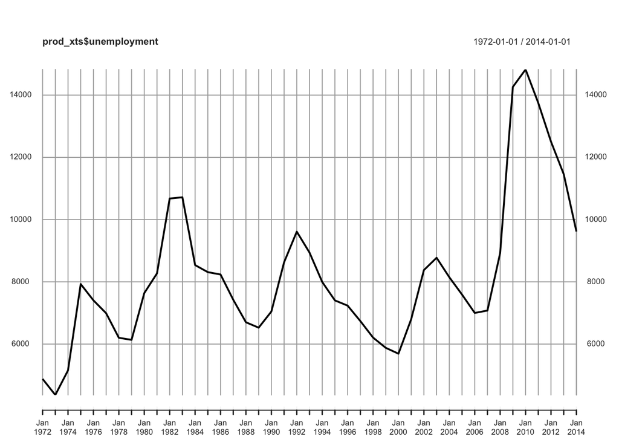

```r
dat_ts <- ts(dat, frequency = 1, start = 1972)
prod_xts <- as.xts(dat_ts)
plot(prod_xts$unemployment)
```

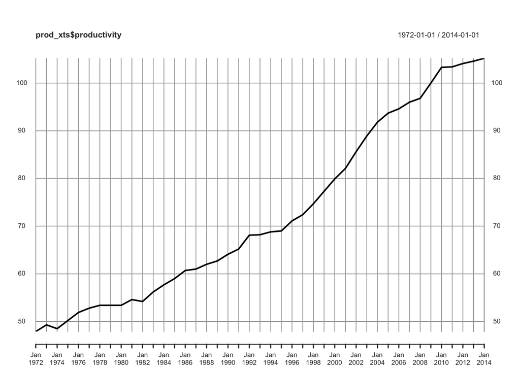

```r
plot(prod_xts$productivity)
```

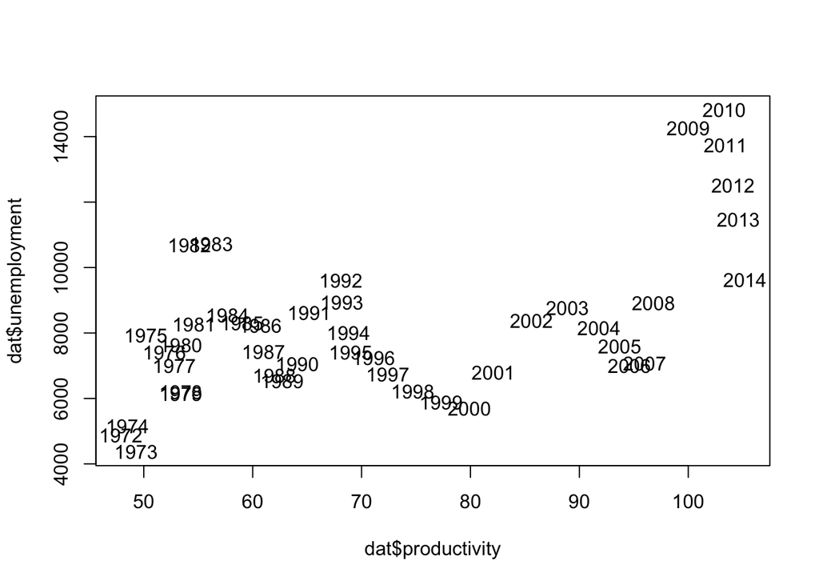

```r
plot(dat$productivity, dat$unemployment, cex = 0)
text(dat$productivity, dat$unemployment, label = dat$year)
```

(b) Test the theory that productivity gains lead to higher unemployment using simple OLS regression. Show your results and interpret them.

```r
summary(model1 <- lm(unemployment ~ productivity, data = dat))
```

```
##
## Call:
## lm(formula = unemployment ~ productivity, data = dat)
##
## Residuals:
##     Min      1Q  Median      3Q     Max
## -3038.4 -1378.9  -550.6  1064.2  4416.8
##
## Coefficients:
##              Estimate Std. Error t value Pr(>|t|)
## (Intercept)   3001.78    1206.67   2.488    0.017 *
## productivity    71.70      16.12   4.448 6.48e-05 ***
## ---
## Signif. codes:  0 '***' 0.001 '**' 0.01 '*' 0.05 '.' 0.1 ' ' 1
##
## Residual standard error: 1970 on 41 degrees of freedom
## Multiple R-squared:  0.3255, Adjusted R-squared:  0.3091
## F-statistic: 19.79 on 1 and 41 DF,  p-value: 6.48e-05
```

(c) Test the variables from the previous regression for stationarity. Show your code, results and interpret them briefly. Should you trust your results from the first regression?

```r
# simple test for a linear trend
summary(lm(unemployment ~ year, data = dat))
```

```
##
## Call:
## lm(formula = unemployment ~ year, data = dat)
##
## Residuals:
##     Min      1Q  Median      3Q     Max
## -3219.6 -1225.4  -474.4  1080.2  4897.4
##
## Coefficients:
##               Estimate Std. Error t value Pr(>|t|)
## (Intercept) -194286.26   49514.43  -3.924 0.000325 ***
## year            101.60      24.84   4.090 0.000197 ***
## ---
## Signif. codes:  0 '***' 0.001 '**' 0.01 '*' 0.05 '.' 0.1 ' ' 1
##
## Residual standard error: 2022 on 41 degrees of freedom
## Multiple R-squared:  0.2897, Adjusted R-squared:  0.2724
## F-statistic: 16.72 on 1 and 41 DF,  p-value: 0.0001968
```

```r
summary(lm(productivity ~ year, data = dat))
```

```
##
## Call:
## lm(formula = productivity ~ year, data = dat)
##
## Residuals:
##     Min      1Q  Median      3Q     Max
## -6.4501 -3.0422 -0.1512  3.3199  6.2962
##
## Coefficients:
##               Estimate Std. Error t value Pr(>|t|)
## (Intercept) -2.860e+03  9.365e+01  -30.54   <2e-16 ***
## year         1.472e+00  4.699e-02   31.32   <2e-16 ***
## ---
## Signif. codes:  0 '***' 0.001 '**' 0.01 '*' 0.05 '.' 0.1 ' ' 1
##
## Residual standard error: 3.824 on 41 degrees of freedom
## Multiple R-squared:  0.9599, Adjusted R-squared:  0.9589
## F-statistic: 980.9 on 1 and 41 DF,  p-value: < 2.2e-16
```

```r
# testing for stationarity with the Augmented Dickey-Fuller test
adf.test(dat$unemployment)
```

```
##
##  Augmented Dickey-Fuller Test
##
## data:  dat$unemployment
## Dickey-Fuller = -2.6267, Lag order = 3, p-value = 0.3261
## alternative hypothesis: stationary
```

```r
adf.test(dat$productivity)
```

```
##
##  Augmented Dickey-Fuller Test
##
## data:  dat$productivity
## Dickey-Fuller = -1.8833, Lag order = 3, p-value = 0.6198
## alternative hypothesis: stationary
```

(d) Besides the issue of stationarity, you remember there may also be a problem with dependence. You have a good reason to believe that previous unemployment levels will have an effect on current levels of unemployment (you might be suspecting an AR(1) process). Carry out a statistical test for an AR(1) process in unemployment. Show your work and interpret the result.

```r
summary(lm(unemployment ~ lag(unemployment, 1), data = dat))
```

```
##
## Call:
## lm(formula = unemployment ~ lag(unemployment, 1), data = dat)
##
## Residuals:
##     Min      1Q  Median      3Q     Max
## -1836.6  -765.4  -401.3   415.1  5363.1
##
## Coefficients:
##                       Estimate Std. Error t value Pr(>|t|)
## (Intercept)          1.567e+03  7.176e+02   2.184   0.0349 *
## lag(unemployment, 1) 8.219e-01  8.441e-02   9.737 4.15e-12 ***
## ---
## Signif. codes:  0 '***' 0.001 '**' 0.01 '*' 0.05 '.' 0.1 ' ' 1
##
## Residual standard error: 1291 on 40 degrees of freedom
##   (1 observation deleted due to missingness)
## Multiple R-squared:  0.7033, Adjusted R-squared:  0.6959
## F-statistic:  94.8 on 1 and 40 DF,  p-value: 4.146e-12
```

(e) Plot the autocorrelation of unemployment. What does it show you?

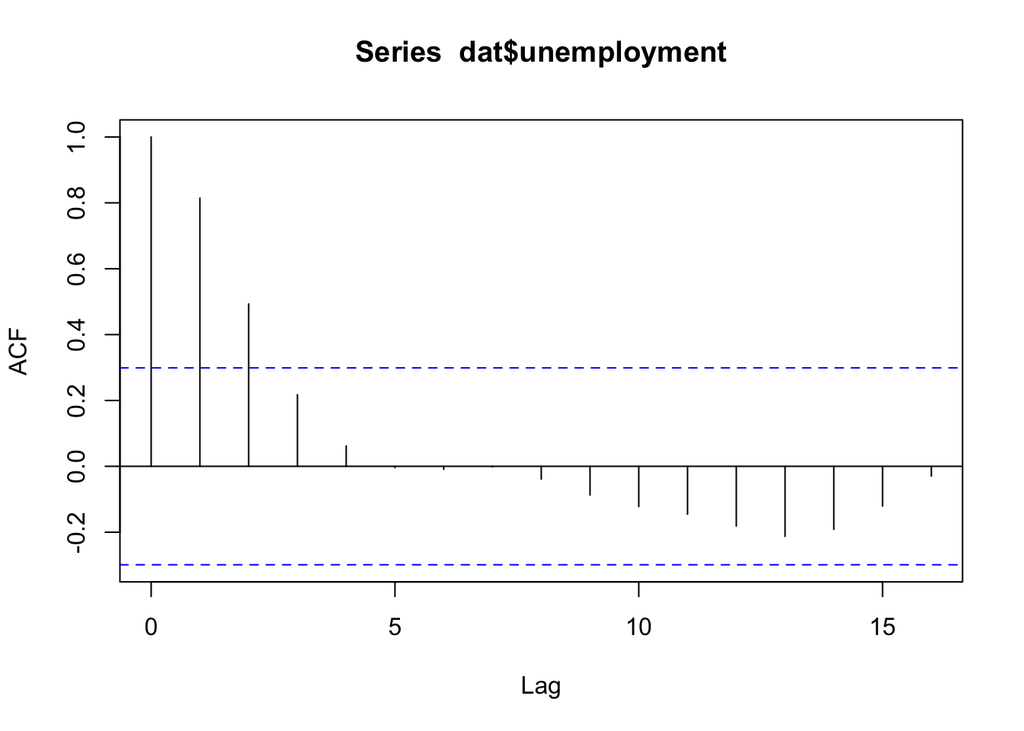

```r
acf(dat$unemployment, na.action = na.pass)
```

(f) To address the issues of stationarity and autocorrelation, try first-differencing for both variables (there’s a simple function in `R` - google for it), and then inspect the autocorrelation of both variables again. What do you see?

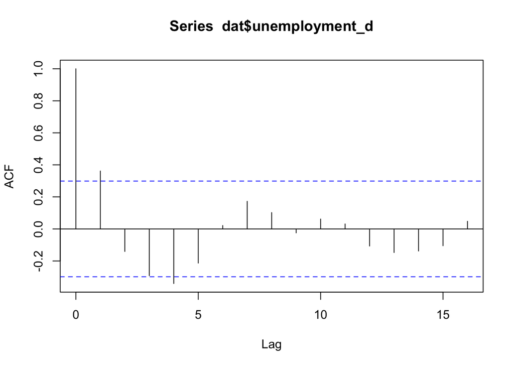

```r
dat$unemployment_d <- c(NA, diff(dat$unemployment))
dat$productivity_d <- c(NA, diff(dat$productivity))
acf(dat$unemployment_d, na.action = na.pass)
```

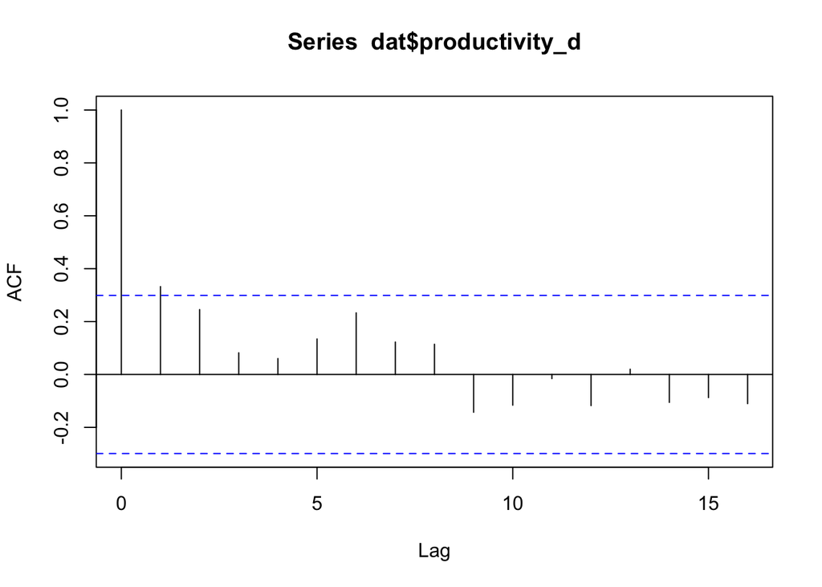

```r
acf(dat$productivity_d, na.action = na.pass)
```

(g) Now, run a regression of the differenced time series and interpret the results. Finally, come up with additional hypotheses that relate to the other variables in the dataset, and test these!

```r
summary(model_out <- lm(unemployment_d ~ productivity_d + corp_prft_finance, data = dat))
```

```
##
## Call:
## lm(formula = unemployment_d ~ productivity_d + corp_prft_finance,
##     data = dat)
##
## Residuals:
##     Min      1Q  Median      3Q     Max
## -2571.0  -776.1  -382.0   251.7  4870.5
##
## Coefficients:
##                   Estimate Std. Error t value Pr(>|t|)
## (Intercept)       -118.957    367.292  -0.324   0.7478
## productivity_d     381.592    197.586   1.931   0.0607 .
## corp_prft_finance   -1.741      1.465  -1.188   0.2420
## ---
## Signif. codes:  0 '***' 0.001 '**' 0.01 '*' 0.05 '.' 0.1 ' ' 1
##
## Residual standard error: 1310 on 39 degrees of freedom
##   (1 observation deleted due to missingness)
## Multiple R-squared:  0.09649,    Adjusted R-squared:  0.05015
## F-statistic: 2.082 on 2 and 39 DF,  p-value: 0.1383
```